# Digital Guard - Apresentação

Author

data@addressforall.org

Published

14/06/2022

Os endereços são parte fundamental da infraestrutura física-territorial de um país. Eles são essenciais para a provisão de serviços básicos (eletricidade, água, correio), no planejamento e implementação de políticas públicas e no desenvolvimento do setor privado.

O Instituto AddressForAll já atua em **8 países** da América Latina por meio do Projeto Digital Guard. **35 doadores** contribuíram para a plataforma de dados.

[interactive chart not shown]

# Documentos de referência

Após recebimento dos dados, eles são publicados em [três formatos/estágios](http://addressforall.org/dados):

- Dados preservados
- Dados filtrados
- Dados consolidados

O [dicionário de dados](https://github.com/digital-guard/preserv/blob/main/docs/pt/ftypes.md) descreve quais tipos de layer são adicionadas à plataforma de dados atualmente.

*Layers* contendo o endereço:

- **geoaddress**: Geo-endereço. Representação geográfica do endereço, como ponto.
- **building**: Polígono de edificação.
- **parcel**: Polígono de lote (terreno).

*Layers* de apoio e complementação dos dados de endereço:

- **via**: Eixo de via. Logradouro representado por linha central, com nome oficial.
- **genericvia**: Ferrovia, hidrovia ou outra “via generalizada” que ajude a delimitar quadras.
- **block**: Quadras ou divisões poligonais similares.
- **nsvia**: *NameSpace* para distinguir vias duplicadas, tipicamente bairro ou loteamento.

A política de licenças adotada pelo Instituto foi detalhada [neste repositório](https://github.com/digital-guard/licenses).

## Dados preservados

**118 layers** já foram preservados, recebidas de **35 doadores**

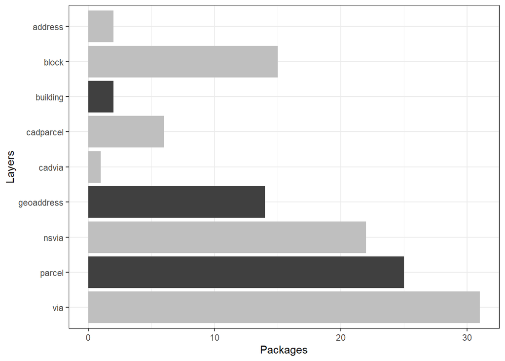

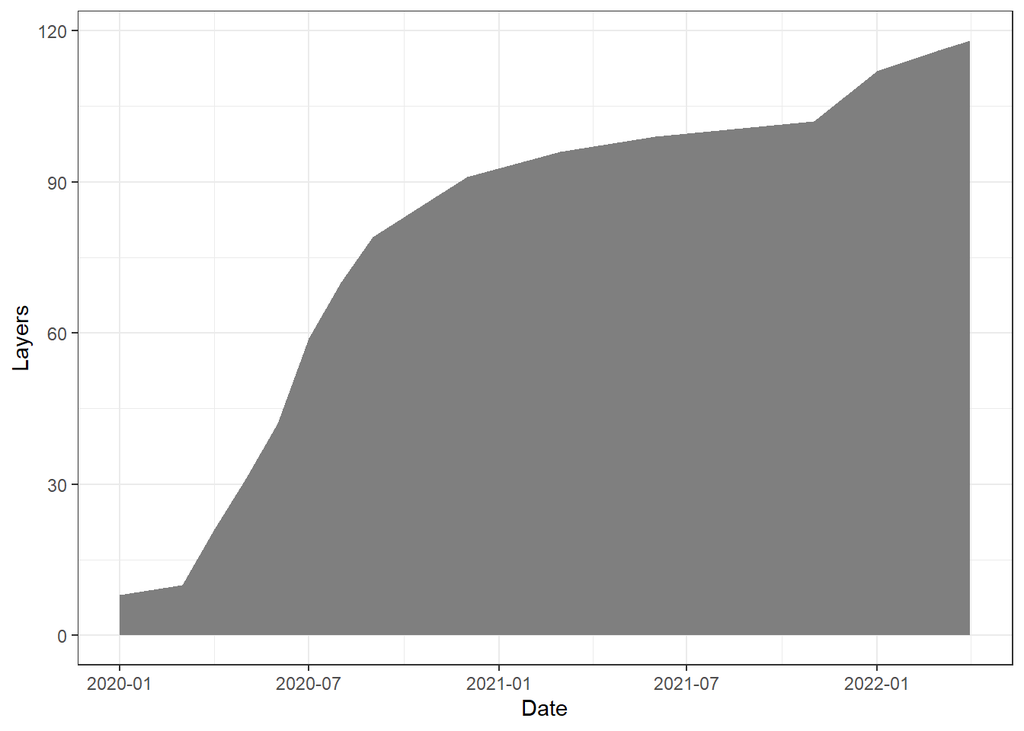

## Dados filtrados

### Geoendereços

**5.388.682 geoendereços com licença da família CC0**, compartilhados por **20 doadores**

**3.387.546 geoendereços com licença da família CC0 explícita**, compartilhados por **7 doadores**

| License family | Donors | Addresses |
| --- | --- | --- |
| CC0 (implicit) | 13 | 2.001.136 |
| CC0 (explicit) | 7 | 3.387.546 |
| CC-BY (explicit) | 1 | 1.000.830 |
| CC-BY-SA (explicit) | 1 | 508.562 |

## Dados consolidados

Ainda não está em operação.

## Pacotes doados para consulta - apenas dados completos/full (ver dicionário de dados)

| Jurisdiction | Donor | Layer | # of features | License family | License type |
| --- | --- | --- | --- | --- | --- |
| BR | OpenStreetMap Foundation | via | 2.817.747 | CC-BY-SA | explicit |
| BR | Instituto Brasileiro de Geografia e Estatística | via | 136.957 | CC0 | explicit |
| BR | OpenStreetMap Foundation | via | 4.856.390 | CC-BY-SA | explicit |
| BR | OpenStreetMap Foundation | geoaddress | 508.562 | CC-BY-SA | explicit |
| BR | OpenStreetMap Foundation | geoaddress | 1.101.237 | CC-BY-SA | explicit |
| BR | Instituto Brasileiro de Geografia e Estatística | geoaddress | 1.793.783 | CC0 | explicit |
| BR-AC-RioBranco | Prefeitura Municipal de Rio Branco | block | 21.430 | CC0 | implicit |
| BR-AC-RioBranco | Prefeitura Municipal de Rio Branco | via | 3.181 | CC0 | implicit |
| BR-AC-RioBranco | Prefeitura Municipal de Rio Branco | nsvia | 208 | CC0 | implicit |
| BR-AC-RioBranco | Prefeitura Municipal de Rio Branco | parcel | 106.493 | CC0 | implicit |

[output cut: 64 more lines]